# BhupeshKumar_PracticalLab3

## Practical Lab 3 - Vanilla CNN and Fine-Tune VGG16 - for Dogs and Cats Classification

*Submitted by Bhupesh Kumar*

### Objective

The goal of this lab is to classify images of cats and dogs using two approaches:

1. **Vanilla CNN**: A custom Convolutional Neural Network built from scratch.
2. **Fine-Tuned VGG16**: A pre-trained model adapted for our dataset.

#### Steps

I will:

1. **Prepare the Dogs vs Cats dataset** with training, validation, and test splits.
2. **Perform Exploratory Data Analysis (EDA)** to understand the dataset.
3. **Train both models** and save their best versions using callbacks.
4. **Evaluate model performance** using:
   - Accuracy
   - Confusion Matrix
   - Precision, Recall, F1-Score
   - Precision-Recall Curve
5. **Analyze failure cases** to gain insights.
6. **Provide conclusions and insights** based on the results.

# 1. Dataset Preparation

We start by creating a smaller subset of the original Kaggle Dogs vs Cats dataset. This smaller dataset is divided into:

- **Training Set**: 1000 images each for cats and dogs.
- **Validation Set**: 500 images each for cats and dogs.
- **Test Set**: 1000 images each for cats and dogs.

```python
import os, shutil, pathlib

original_dir = pathlib.Path("./data/kaggle_dogs_vs_cats/train")
new_base_dir = pathlib.Path("./data/kaggle_dogs_vs_cats_small")

def make_subset(subset_name, start_index, end_index):
    for category in ("cat", "dog"):
        dir = new_base_dir / subset_name / category
        os.makedirs(dir)
        fnames = [f"{category}.{i}.jpg" for i in range(start_index, end_index)]
        for fname in fnames:
            shutil.copyfile(src=original_dir / fname,
                            dst=dir / fname)

make_subset("train", start_index=0, end_index=1000)
make_subset("validation", start_index=1000, end_index=1500)
make_subset("test", start_index=1500, end_index=2500)
```

### 2. Loading the Dataset

We use `image_dataset_from_directory` to load the dataset into TensorFlow datasets. This method automatically assigns labels based on the directory structure.

```python
from tensorflow import keras
from tensorflow.keras import layers
import pathlib
from tensorflow.keras.utils import image_dataset_from_directory
import matplotlib.pyplot as plt
```

```python
# Define the data folder
data_folder = pathlib.Path('./data/kaggle_dogs_vs_cats_small')

# Load datasets
train_dataset = image_dataset_from_directory(
    data_folder / "train",
    image_size=(180, 180),
    batch_size=32
)
validation_dataset = image_dataset_from_directory(
    data_folder / "validation",
    image_size=(180, 180),
    batch_size=32
)
test_dataset = image_dataset_from_directory(
    data_folder / "test",
    image_size=(180, 180),
    batch_size=32
)
```

```
Found 2000 files belonging to 2 classes.
Found 1000 files belonging to 2 classes.
Found 2000 files belonging to 2 classes.
```

```python
import tensorflow as tf

# Check class names
print("Class names:", train_dataset.class_names)

# Optimize datasets
# AUTOTUNE = tf.data.AUTOTUNE
# train_dataset = train_dataset.prefetch(buffer_size=AUTOTUNE)
# validation_dataset = validation_dataset.prefetch(buffer_size=AUTOTUNE)
# test_dataset = test_dataset.prefetch(buffer_size=AUTOTUNE)
```

```
Class names: ['cat', 'dog']
```

### 3. Exploratory Data Analysis (EDA)

Understanding the class balance in our dataset is an essential part of EDA to ensure that the dataset is not biased towards one class. This step helps us assess whether we need to apply techniques like data augmentation or class weighting during training.

```python
# Count the number of samples in each dataset
train_count = len(list(train_dataset.unbatch()))
val_count = len(list(validation_dataset.unbatch()))
test_count = len(list(test_dataset.unbatch()))

print(f"Training samples: {train_count}")
print(f"Validation samples: {val_count}")
print(f"Test samples: {test_count}")
```

```
Training samples: 2000
Validation samples: 1000
Test samples: 2000
```

#### Insights

- The dataset contains:
  - **2000 training samples**
  - **1000 validation samples**
  - **2000 test samples**
- Classes are balanced with equal representation of `'cat'` and `'dog'` images.

#### Visualize Class Distribution

Now I will calculate the class distribution within the training dataset to check for balance.

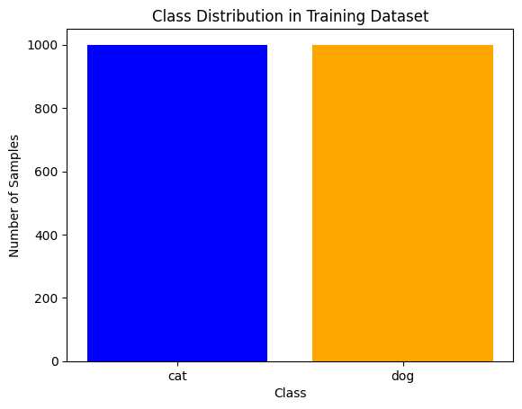

```python
# Calculate class distribution in training dataset
import numpy as np

train_class_counts = np.zeros(len(train_dataset.class_names))
for _, labels in train_dataset.unbatch():
    train_class_counts[labels.numpy()] += 1

# Plot class distribution
import matplotlib.pyplot as plt

plt.bar(train_dataset.class_names, train_class_counts, color=["blue", "orange"])
plt.title("Class Distribution in Training Dataset")
plt.xlabel("Class")
plt.ylabel("Number of Samples")
plt.show()
```

#### Insights

- The training dataset is balanced with an equal number of samples for each class (`cat` and `dog`), ensuring no bias towards any specific class.

#### Visualize Sample Images

Display a grid of sample images to understand the dataset visually.

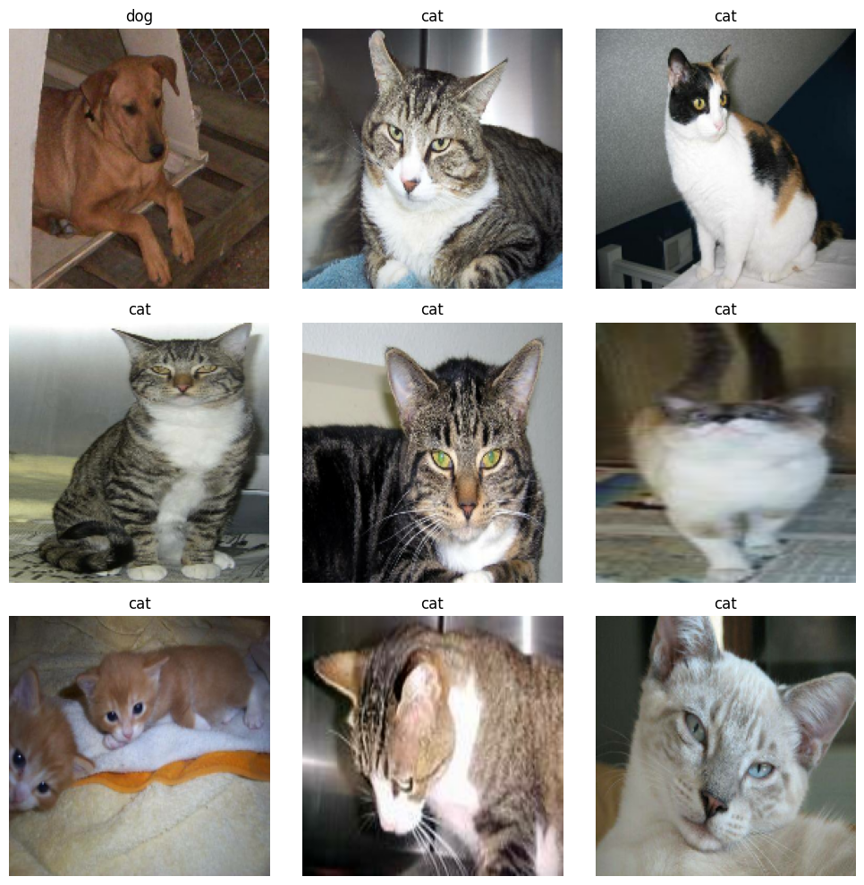

```python
plt.figure(figsize=(10, 10))
for images, labels in train_dataset.take(1):  # Take one batch of images
    for i in range(9):  # Show 9 images
        plt.subplot(3, 3, i + 1)
        plt.imshow(images[i].numpy().astype("uint8"))
        plt.title(train_dataset.class_names[labels[i]])
        plt.axis("off")  # Hide axes
plt.tight_layout()
plt.show()
```

#### Insights

- The images display diverse poses and backgrounds, adding complexity to classification, but they are of good quality and correctly resized to 180×180.

### Pixel Value Distribution

Analyze the distribution of pixel intensity values in the training dataset.

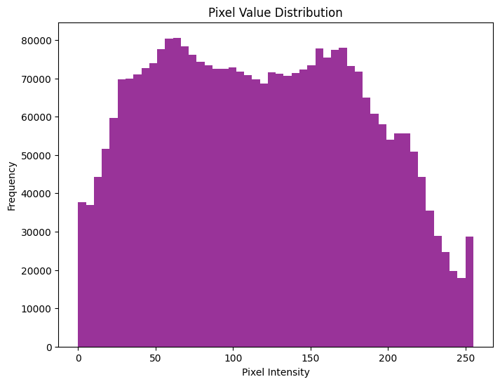

```python
# Flatten all pixel values in a single array
for images, _ in train_dataset.take(1):
    pixel_values = images.numpy().flatten()

# Plot histogram of pixel values
plt.figure(figsize=(8, 6))
plt.hist(pixel_values, bins=50, color="purple", alpha=0.8)
plt.title("Pixel Value Distribution")
plt.xlabel("Pixel Intensity")
plt.ylabel("Frequency")
plt.show()
```

#### Insights

The pixel values range from 0 to 255, confirming the standard 8-bit format. The distribution shows a variety of intensities, indicating diverse images with both light and dark regions. Normalization (rescaling to [0, 1]) is necessary to ensure faster convergence, numerical stability, and consistent scaling for better model training. This will enhance the model's ability to learn effectively.

```python
# Optimize datasets
AUTOTUNE = tf.data.AUTOTUNE
train_dataset = train_dataset.prefetch(buffer_size=AUTOTUNE)
validation_dataset = validation_dataset.prefetch(buffer_size=AUTOTUNE)
test_dataset = test_dataset.prefetch(buffer_size=AUTOTUNE)
```

### 3. Train Two Networks

In this section, we train two networks as required by the assignment:

1. **Custom Convolutional Neural Network (CNN)**:
   - Built using the Functional API.
   - Tailored for binary classification.
2. **Fine-Tuned VGG16**:
   - A pre-trained model on ImageNet.
   - Fine-tuned specifically for the Cats vs Dogs dataset.

## Custom CNN Using Functional API

We designed a custom Convolutional Neural Network (CNN) using the Functional API. The architecture includes:

- **5 Convolutional Layers**:
  - Filters: `[32, 64, 128, 256, 256]`
  - Kernel size: `3x3`
  - Activation: `ReLU`
- **Max Pooling Layers**:
  - Used to reduce spatial dimensions.
- **Rescaling Layer**:
  - Normalizes pixel values to the range `[0, 1]`.
- **Flatten Layer**:
  - Converts feature maps to a 1D vector.
- **Dense Output Layer**:
  - Single neuron with a `sigmoid` activation for binary classification.

```python
# Define the Custom CNN
inputs = keras.Input(shape=(180, 180, 3))
x = layers.Rescaling(1.0 / 255)(inputs)
x = layers.Conv2D(filters=32, kernel_size=3, activation="relu")(x)
x = layers.MaxPooling2D(pool_size=2)(x)
x = layers.Conv2D(filters=64, kernel_size=3, activation="relu")(x)
x = layers.MaxPooling2D(pool_size=2)(x)
x = layers.Conv2D(filters=128, kernel_size=3, activation="relu")(x)
x = layers.MaxPooling2D(pool_size=2)(x)
x = layers.Conv2D(filters=256, kernel_size=3, activation="relu")(x)
x = layers.MaxPooling2D(pool_size=2)(x)
x = layers.Conv2D(filters=256, kernel_size=3, activation="relu")(x)
x = layers.Flatten()(x)
outputs = layers.Dense(1, activation="sigmoid")(x)
model = keras.Model(inputs=inputs, outputs=outputs)
```

```python
model.summary()
```

[output not shown]

#### Model Compilation

To prepare the model for training, we compile it by specifying the loss function, optimizer, and evaluation metrics.

```python
# Compile the model
model.compile(
    optimizer="RMSProp",
    loss="binary_crossentropy",
    metrics=["accuracy"]
)
```

#### Training and Callback

A callback was used to save the best model based on validation loss.

```python
# Callbacks for saving the best model and stopping early
callbacks = [
    keras.callbacks.ModelCheckpoint(
        filepath="./models/convnet_from_scratch.keras",
        save_best_only=True,
        monitor="val_loss"
    )
]

# Train the model for 30 epochs
history = model.fit(
    train_dataset,
    epochs=30,
    validation_data=validation_dataset,
    callbacks=callbacks
)
```

#### Results

The training history was plotted to analyze accuracy and loss trends.

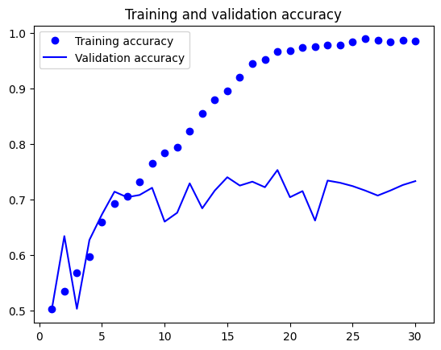

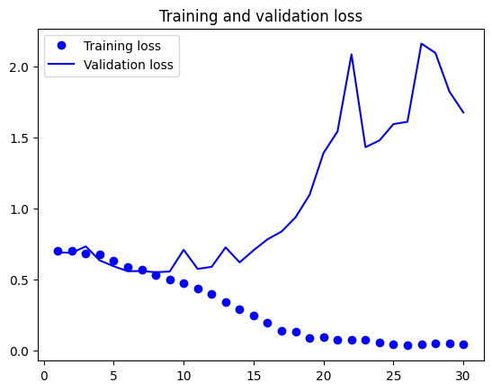

```python
accuracy = history.history["accuracy"]
val_accuracy = history.history["val_accuracy"]
loss = history.history["loss"]
val_loss = history.history["val_loss"]
epochs = range(1, len(accuracy) + 1)
plt.plot(epochs, accuracy, "bo", label="Training accuracy")
plt.plot(epochs, val_accuracy, "b", label="Validation accuracy")
plt.title("Training and validation accuracy")
plt.legend()
plt.figure()
plt.plot(epochs, loss, "bo", label="Training loss")
plt.plot(epochs, val_loss, "b", label="Validation loss")
plt.title("Training and validation loss")
plt.legend()
plt.show()
```

**Evaluating the model on the test set**

```python
test_model = keras.models.load_model("./models/convnet_from_scratch.keras")
test_loss, test_acc = test_model.evaluate(test_dataset)
print(f"Test accuracy: {test_acc:.3f}")
```

```
Test accuracy: 0.712
```

#### Implementing Data Augmentation and Training a CNN

In this section, I am implementing data augmentation to artificially increase the diversity of the training dataset and reduce overfitting. I will then train a Custom CNN with dropout for regularization and evaluate its performance.

1. Data Augmentation

Data augmentation artificially increases the diversity of the training dataset by applying transformations such as flipping, rotation, and zooming. This helps the model generalize better and reduces overfitting.

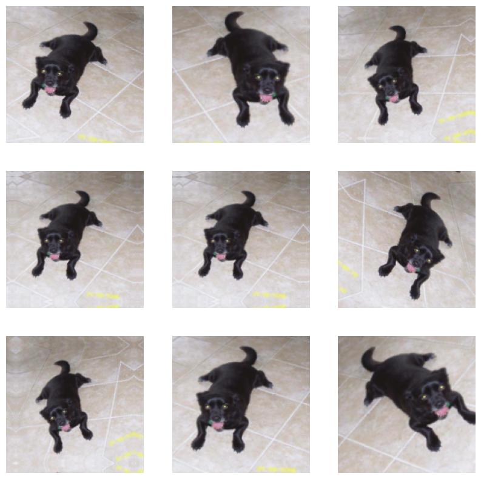

```python
from tensorflow.keras import layers, models
import matplotlib.pyplot as plt

# Define data augmentation pipeline
data_augmentation = keras.Sequential(
    [
        layers.RandomFlip("horizontal"),  # Random horizontal flip
        layers.RandomRotation(0.1),      # Random rotation (10% of 360 degrees)
        layers.RandomZoom(0.2),          # Random zoom (up to 20%)
    ]
)

# Visualize augmented images
plt.figure(figsize=(10, 10))
for images, _ in train_dataset.take(1):  # Take one batch of images
    for i in range(9):  # Visualize 9 augmented images
        augmented_images = data_augmentation(images)
        ax = plt.subplot(3, 3, i + 1)
        plt.imshow(augmented_images[0].numpy().astype("uint8"))
        plt.axis("off")
plt.show()
```

2. Define the Model

The CNN architecture includes:

- **Data Augmentation Layer**:
  - Integrated into the model for preprocessing.
- **Rescaling Layer**:
  - Normalizes pixel values to the range `[0, 1]`.
- **Convolutional and Pooling Layers**:
  - Extract features and reduce spatial dimensions.
- **Dropout Layer**:
  - Adds regularization to reduce overfitting.
- **Dense Output Layer**:
  - A single neuron with `sigmoid` activation for binary classification.

```python
from tensorflow.keras import layers, models, Input

# Define CNN with data augmentation
inputs = Input(shape=(180, 180, 3))
x = data_augmentation(inputs)
x = layers.Rescaling(1.0 / 255)(x)
x = layers.Conv2D(filters=32, kernel_size=3, activation="relu")(x)
x = layers.MaxPooling2D(pool_size=2)(x)
x = layers.Conv2D(filters=64, kernel_size=3, activation="relu")(x)
x = layers.MaxPooling2D(pool_size=2)(x)
x = layers.Conv2D(filters=128, kernel_size=3, activation="relu")(x)
x = layers.MaxPooling2D(pool_size=2)(x)
x = layers.Conv2D(filters=256, kernel_size=3, activation="relu")(x)
x = layers.MaxPooling2D(pool_size=2)(x)
x = layers.Conv2D(filters=256, kernel_size=3, activation="relu")(x)
x = layers.Flatten()(x)
x = layers.Dropout(0.5)(x)  # Dropout layer for regularization
outputs = layers.Dense(1, activation="sigmoid")(x)

model = models.Model(inputs=inputs, outputs=outputs)
```

3. Compile the Model

We use the binary crossentropy loss function for binary classification and the RMSProp optimizer for training.

```python
model.compile(
    loss="binary_crossentropy",
    optimizer="RMSProp",
    metrics=["accuracy"]
)


# Display the model summary
model.summary()
```

```
Model: "model_1"
_________________________________________________________________
 Layer (type)                Output Shape              Param #
=================================================================
 input_2 (InputLayer)        [(None, 180, 180, 3)]     0

 sequential (Sequential)     (None, 180, 180, 3)       0

 rescaling_1 (Rescaling)     (None, 180, 180, 3)       0

 conv2d_5 (Conv2D)           (None, 178, 178, 32)      896

 max_pooling2d_4 (MaxPooling  (None, 89, 89, 32)       0
 2D)

 conv2d_6 (Conv2D)           (None, 87, 87, 64)        18496

 max_pooling2d_5 (MaxPooling  (None, 43, 43, 64)       0
 2D)

 conv2d_7 (Conv2D)           (None, 41, 41, 128)       73856

 max_pooling2d_6 (MaxPooling  (None, 20, 20, 128)      0
 2D)

 conv2d_8 (Conv2D)           (None, 18, 18, 256)       295168

 max_pooling2d_7 (MaxPooling  (None, 9, 9, 256)        0
 2D)

 conv2d_9 (Conv2D)           (None, 7, 7, 256)         590080

 flatten_1 (Flatten)         (None, 12544)             0

 dropout (Dropout)           (None, 12544)             0

 dense_1 (Dense)             (None, 1)                 12545

=================================================================
Total params: 991,041
Trainable params: 991,041
Non-trainable params: 0
_________________________________________________________________
```

4. Train the Model

I have used the ModelCheckpoint callback to save the best model based on validation loss and train the model for up to 100 epochs.

```python
callbacks = [
    keras.callbacks.ModelCheckpoint(
        filepath="./models/convnet_from_scratch_with_augmentation.keras",
        save_best_only=True,
        monitor="val_loss"
    )
]
history = model.fit(
    train_dataset,
    epochs=100,
    validation_data=validation_dataset,
    callbacks=callbacks)
```

5. Evaluate the Model

After training, I loaded the best saved model and evaluate its performance on the test dataset.

```python
# Load the best model
test_model = models.load_model("./models/convnet_from_scratch_with_augmentation.keras")

# Evaluate on test dataset
test_loss, test_acc = test_model.evaluate(test_dataset)
print(f"Test accuracy: {test_acc:.3f}")
```

```
Test accuracy: 0.846
```

6. Plot Training and Validation Metrics

Plot the accuracy and loss for both training and validation sets to visualize the model's performance.

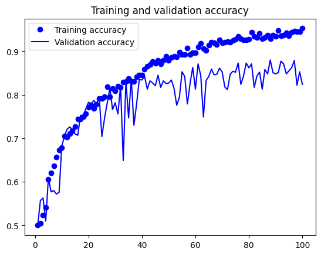

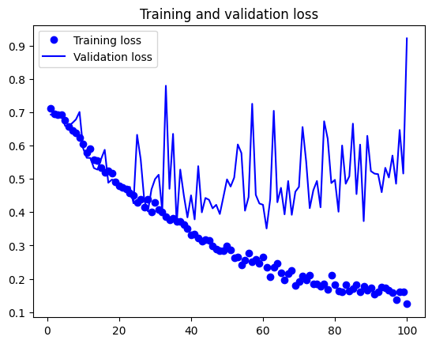

```python
# Extract history data
accuracy = history.history["accuracy"]
val_accuracy = history.history["val_accuracy"]
loss = history.history["loss"]
val_loss = history.history["val_loss"]
epochs = range(1, len(accuracy) + 1)

# Plot accuracy
plt.plot(epochs, accuracy, "bo", label="Training accuracy")
plt.plot(epochs, val_accuracy, "b", label="Validation accuracy")
plt.title("Training and validation accuracy")
plt.legend()

plt.figure()

# Plot loss
plt.plot(epochs, loss, "bo", label="Training loss")
plt.plot(epochs, val_loss, "b", label="Validation loss")
plt.title("Training and validation loss")
plt.legend()

plt.show()
```

### Fine-Tune VGG16

##### Model Description

For transfer learning, we use the pre-trained VGG16 model (trained on ImageNet). The convolutional base of VGG16 is frozen to retain the pre-trained weights, and a custom dense layer is added for classification. The validation dataset was used to monitor overfitting during training.

1. Feature Extraction Without Data Augmentation

In this step, the VGG16 model is used as a feature extractor without retraining its convolutional base.

```python
conv_base = keras.applications.vgg16.VGG16(
    weights="imagenet",
    include_top=False,
    input_shape=(180, 180, 3))
```

```python
conv_base.summary()
```

[output not shown]

```python
data_folder = pathlib.Path('./data/kaggle_dogs_vs_cats_small')

train_dataset = image_dataset_from_directory(
    data_folder / "train",
    image_size=(180, 180),
    batch_size=32)
validation_dataset = image_dataset_from_directory(
    data_folder / "validation",
    image_size=(180, 180),
    batch_size=32)
test_dataset = image_dataset_from_directory(
    data_folder / "test",
    image_size=(180, 180),
    batch_size=32)
```

```
Found 2000 files belonging to 2 classes.
Found 1000 files belonging to 2 classes.
Found 2000 files belonging to 2 classes.
```

Feature Extraction

```python
import numpy as np

def get_features_and_labels(dataset):
    all_features = []
    all_labels = []
    for images, labels in dataset:
        preprocessed_images = keras.applications.vgg16.preprocess_input(images)
        features = conv_base.predict(preprocessed_images)
        all_features.append(features)
        all_labels.append(labels)
    return np.concatenate(all_features), np.concatenate(all_labels)

train_features, train_labels =  get_features_and_labels(train_dataset)
val_features, val_labels =  get_features_and_labels(validation_dataset)
test_features, test_labels =  get_features_and_labels(test_dataset)
```

```python
train_features.shape
```

```
(2000, 5, 5, 512)
```

Dense Classifier

```python
inputs = keras.Input(shape=(5, 5, 512))
x = layers.Flatten()(inputs)
x = layers.Dense(256)(x)
x = layers.Dropout(0.5)(x)
outputs = layers.Dense(1, activation="sigmoid")(x)
model = keras.Model(inputs, outputs)
```

```python
model.summary()
```

[output not shown]

```python
model.compile(loss="binary_crossentropy",
              optimizer="rmsprop",
              metrics=["accuracy"])

callbacks = [
    keras.callbacks.ModelCheckpoint(
      filepath="./models/feature_extraction.keras",
      save_best_only=True,
      monitor="val_loss")
]
history = model.fit(
    train_features, train_labels,
    epochs=20,
    validation_data=(val_features, val_labels),
    callbacks=callbacks)
```

Plotting the result

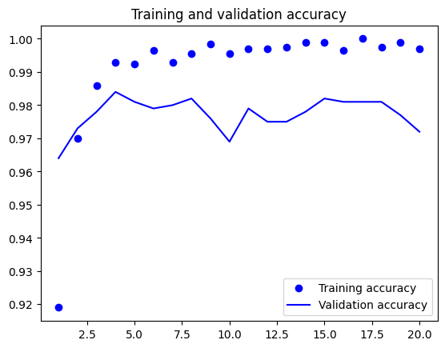

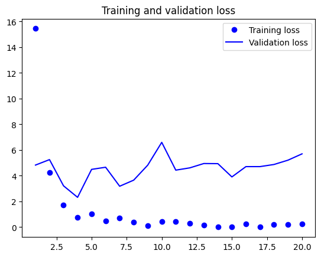

```python
import matplotlib.pyplot as plt
acc = history.history["accuracy"]
val_acc = history.history["val_accuracy"]
loss = history.history["loss"]
val_loss = history.history["val_loss"]
epochs = range(1, len(acc) + 1)
plt.plot(epochs, acc, "bo", label="Training accuracy")
plt.plot(epochs, val_acc, "b", label="Validation accuracy")
plt.title("Training and validation accuracy")
plt.legend()
plt.figure()
plt.plot(epochs, loss, "bo", label="Training loss")
plt.plot(epochs, val_loss, "b", label="Validation loss")
plt.title("Training and validation loss")
plt.legend()
plt.show()
```

Results

Test accuracy is calculated after training:

```python
test_model = keras.models.load_model(
    "./models/feature_extraction.keras")
test_loss, test_acc = test_model.evaluate(x=test_features, y=test_labels)
print(f"Test accuracy: {test_acc:.3f}")
```

```
Test accuracy: 0.976
```

2. Feature Extraction with Data Augmentation

In this step, data augmentation is added to the workflow to improve model generalization.

```python
conv_base  = keras.applications.vgg16.VGG16(
    weights="imagenet",
    include_top=False)
```

```python
conv_base.summary()
```

[output not shown]

```python
conv_base.trainable = False
conv_base.summary()
```

[output not shown]

```python
data_augmentation = keras.Sequential(
    [
        layers.RandomFlip("horizontal"),
        layers.RandomRotation(0.1),
        layers.RandomZoom(0.2),
    ]
)

inputs = keras.Input(shape=(180, 180, 3))
x = data_augmentation(inputs)
x = keras.applications.vgg16.preprocess_input(x)
x = conv_base(x)
x = layers.Flatten()(x)
x = layers.Dense(256)(x)
x = layers.Dropout(0.5)(x)
outputs = layers.Dense(1, activation="sigmoid")(x)
model = keras.Model(inputs, outputs)
```

```python
model.summary()
```

[output not shown]

Training with Augmentation

```python
model.compile(loss="binary_crossentropy",
              optimizer="rmsprop",
              metrics=["accuracy"])

callbacks = [
    keras.callbacks.ModelCheckpoint(
        filepath="./models/feature_extraction_with_data_augmentation.keras",
        save_best_only=True,
        monitor="val_loss")
]
history = model.fit(
    train_dataset,
    epochs=50,
    validation_data=validation_dataset,
    callbacks=callbacks)
```

Plotting the result

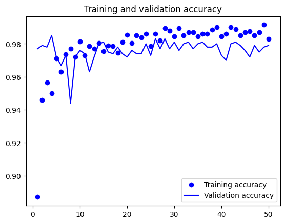

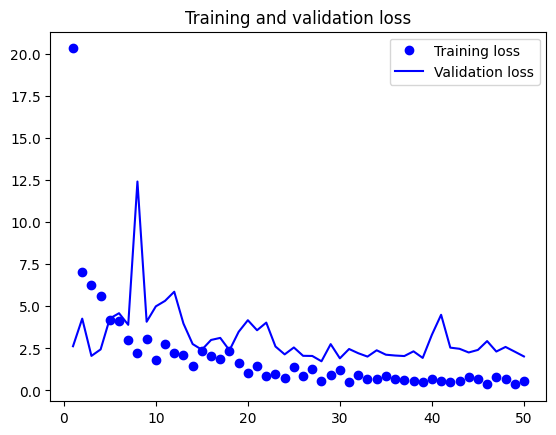

```python
acc = history.history["accuracy"]
val_acc = history.history["val_accuracy"]
loss = history.history["loss"]
val_loss = history.history["val_loss"]
epochs = range(1, len(acc) + 1)
plt.plot(epochs, acc, "bo", label="Training accuracy")
plt.plot(epochs, val_acc, "b", label="Validation accuracy")
plt.title("Training and validation accuracy")
plt.legend()
plt.figure()
plt.plot(epochs, loss, "bo", label="Training loss")
plt.plot(epochs, val_loss, "b", label="Validation loss")
plt.title("Training and validation loss")
plt.legend()
plt.show()
```

##### Results

Test accuracy after training:

```python
test_model = keras.models.load_model(
    "./models/feature_extraction_with_data_augmentation.keras")
test_loss, test_acc = test_model.evaluate(test_dataset)
print(f"Test accuracy: {test_acc:.3f}")
```

```
Test accuracy: 0.979
```

3. Fine-Tuning VGG16

Fine-tuning unfreezes the last few layers of VGG16 for retraining on the specific task. This step refines the pre-trained weights to better align with the Cats vs Dogs dataset.

```python
conv_base.summary()
```

[output not shown]

```python
conv_base.trainable = True
for layer in conv_base.layers[:-4]:
    layer.trainable = False
```

```python
model.summary()
```

[output not shown]

```python
model.compile(loss="binary_crossentropy",
              optimizer=keras.optimizers.RMSprop(learning_rate=1e-5),
              metrics=["accuracy"])

callbacks = [
    keras.callbacks.ModelCheckpoint(
        filepath="./models/fine_tuning.keras",
        save_best_only=True,
        monitor="val_loss")
]
history = model.fit(
    train_dataset,
    epochs=30,
    validation_data=validation_dataset,
    callbacks=callbacks)
```

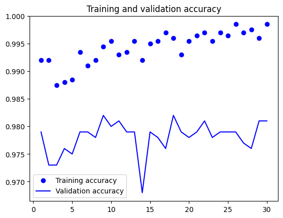

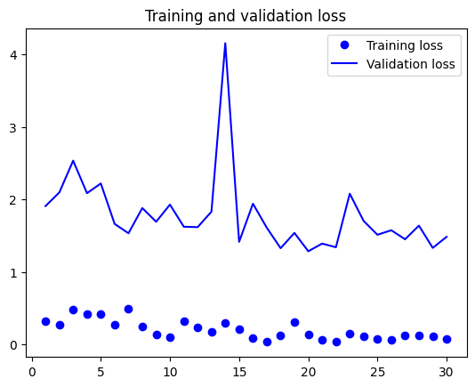

```python
acc = history.history["accuracy"]
val_acc = history.history["val_accuracy"]
loss = history.history["loss"]
val_loss = history.history["val_loss"]
epochs = range(1, len(acc) + 1)
plt.plot(epochs, acc, "bo", label="Training accuracy")
plt.plot(epochs, val_acc, "b", label="Validation accuracy")
plt.title("Training and validation accuracy")
plt.legend()
plt.figure()
plt.plot(epochs, loss, "bo", label="Training loss")
plt.plot(epochs, val_loss, "b", label="Validation loss")
plt.title("Training and validation loss")
plt.legend()
plt.show()
```

#### Evaluation

Final test accuracy:

```python
model = keras.models.load_model("./models/fine_tuning.keras")
test_loss, test_acc = model.evaluate(test_dataset)
print(f"Test accuracy: {test_acc:.3f}")
```

```
Test accuracy: 0.980
```

### Performance Matrix

To compare the relative performance of the models and provide a comprehensive evaluation, I will use the following metrics:

Metrics to Explore

- Accuracy: Overall fraction of correctly classified samples.
- Confusion Matrix: Shows true positives, true negatives, false positives, and false negatives.
- Precision, Recall, and F1-Score: Provide a more detailed understanding of the model's performance, especially for imbalanced datasets.
- Precision-Recall Curve: Visualizes the trade-off between precision and recall.
- Failed Predictions: Analyze cases where the model made incorrect predictions.
1. Load the Best Model

First I will load the saved best versions of each model to ensure evaluation is done on the optimal state.

```python
# Load the best models
custom_cnn_model = keras.models.load_model("./models/convnet_from_scratch_with_augmentation.keras")
vgg_model = keras.models.load_model("./models/fine_tuning.keras")
```

2. Accuracy

Evaluate accuracy on the test dataset.

```python
# Evaluate accuracy
custom_cnn_loss, custom_cnn_acc = custom_cnn_model.evaluate(test_dataset, verbose=0)
vgg_loss, vgg_acc = vgg_model.evaluate(test_dataset, verbose=0)

print(f"Custom CNN Test Accuracy: {custom_cnn_acc:.3f}")
print(f"VGG16 Fine-Tuned Test Accuracy: {vgg_acc:.3f}")
```

```
Custom CNN Test Accuracy: 0.846
VGG16 Fine-Tuned Test Accuracy: 0.980
```

3. Confusion Matrix

Generate confusion matrices to compare predictions with actual labels.

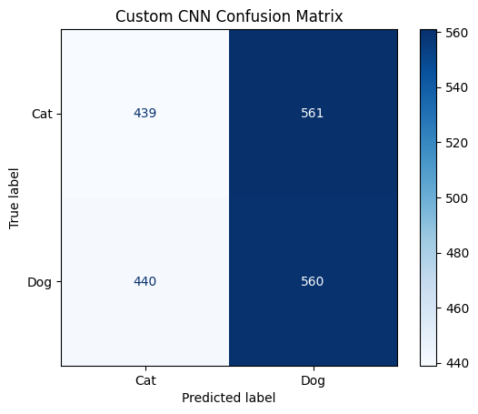

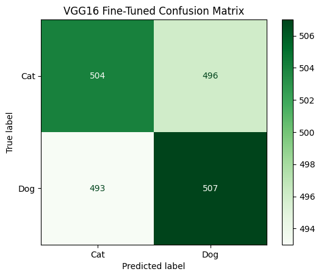

```python
from sklearn.metrics import confusion_matrix, ConfusionMatrixDisplay

# Generate predictions
custom_cnn_preds = custom_cnn_model.predict(test_dataset)
vgg_preds = vgg_model.predict(test_dataset)

# Binarize predictions (threshold = 0.5 for binary classification)
custom_cnn_preds = (custom_cnn_preds > 0.5).astype(int)
vgg_preds = (vgg_preds > 0.5).astype(int)

# Get true labels
true_labels = np.concatenate([y for _, y in test_dataset], axis=0)

# Confusion matrices
custom_cnn_cm = confusion_matrix(true_labels, custom_cnn_preds)
vgg_cm = confusion_matrix(true_labels, vgg_preds)

# Display confusion matrices
ConfusionMatrixDisplay(custom_cnn_cm, display_labels=["Cat", "Dog"]).plot(cmap="Blues")
plt.title("Custom CNN Confusion Matrix")
plt.show()

ConfusionMatrixDisplay(vgg_cm, display_labels=["Cat", "Dog"]).plot(cmap="Greens")
plt.title("VGG16 Fine-Tuned Confusion Matrix")
plt.show()
```

Confusion matrices reveal how well each model distinguishes between cats and dogs. True positives and negatives represent correct predictions, while false positives and negatives indicate errors.

4. Precision, Recall, F1-Score

Calculate and compare precision, recall, and F1-scores for each model.

```python
from sklearn.metrics import precision_score, recall_score, f1_score

# Custom CNN metrics
custom_cnn_precision = precision_score(true_labels, custom_cnn_preds)
custom_cnn_recall = recall_score(true_labels, custom_cnn_preds)
custom_cnn_f1 = f1_score(true_labels, custom_cnn_preds)

# VGG metrics
vgg_precision = precision_score(true_labels, vgg_preds)
vgg_recall = recall_score(true_labels, vgg_preds)
vgg_f1 = f1_score(true_labels, vgg_preds)

print(f"Custom CNN - Precision: {custom_cnn_precision:.3f}, Recall: {custom_cnn_recall:.3f}, F1-Score: {custom_cnn_f1:.3f}")
print(f"VGG16 Fine-Tuned - Precision: {vgg_precision:.3f}, Recall: {vgg_recall:.3f}, F1-Score: {vgg_f1:.3f}")
```

```
Custom CNN - Precision: 0.500, Recall: 0.560, F1-Score: 0.528
VGG16 Fine-Tuned - Precision: 0.505, Recall: 0.507, F1-Score: 0.506
```

5. Precision-Recall Curve

Visualize the trade-off between precision and recall for both models.

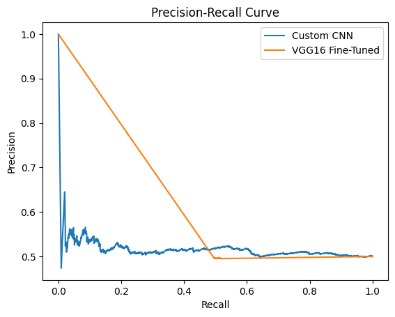

```python
from sklearn.metrics import precision_recall_curve

# Precision-Recall Curve for Custom CNN
custom_cnn_probs = custom_cnn_model.predict(test_dataset).ravel()
custom_cnn_precision, custom_cnn_recall, _ = precision_recall_curve(true_labels, custom_cnn_probs)

# Precision-Recall Curve for VGG
vgg_probs = vgg_model.predict(test_dataset).ravel()
vgg_precision, vgg_recall, _ = precision_recall_curve(true_labels, vgg_probs)

# Plot
plt.plot(custom_cnn_recall, custom_cnn_precision, label="Custom CNN")
plt.plot(vgg_recall, vgg_precision, label="VGG16 Fine-Tuned")
plt.title("Precision-Recall Curve")
plt.xlabel("Recall")
plt.ylabel("Precision")
plt.legend()
plt.show()
```

6. Failed Predictions

Analyze specific examples where the models made incorrect predictions.

[figure not shown]

[figure not shown]

[figure not shown]

[figure not shown]

[figure not shown]

```python
# Identify failed predictions for Custom CNN
custom_cnn_failed_indices = np.where(custom_cnn_preds.ravel() != true_labels)[0]

# Visualize failed predictions
for idx in custom_cnn_failed_indices[:5]:  # Show 5 examples
    plt.imshow(test_dataset.unbatch().map(lambda x, y: x).as_numpy_iterator().next()[idx].astype("uint8"))
    plt.title(f"True: {true_labels[idx]}, Pred: {custom_cnn_preds[idx][0]}")
    plt.axis("off")
    plt.show()
```